# 앞서 분석한 최근 다섯 시즌과 이전 시즌들의 각 스텟과 승률관계 비교

- 앞서 조사한 시즌으로부터 십년 전 자료를 수집해 비교하기로 결정
- 2005/06 시즌의 경우 해당 시즌이 존재하지 않아 2006/07부터 수집
- 총 9개의 시즌 경기를 구했고 이를 과거순대로 4개, 5개로 분리
- 2006/07 ~ 2009/10
- 2010/11 ~ 2014/15
- 2015/16 ~ 2019/20 <- 앞선 분석에서 사용한 가장 최근 시즌경기

## 2006/07 시즌 - 2009/10 시즌

### 라이브러리

```r
library(jsonlite)
library('ggplot2')
library('ggthemes')
```

```r
data = fromJSON('AllTeam06-10.json')
data = data.frame(data)
new_list  <-c('Team','Matchyear','Matchday','WinorLose','Formation','Possession','Shots','Shots_on_target','Touches','Passes','Tackles','Clearances','Corners','Offsides','Yellow_cards','Red_cards','Foul_conceded','num')
colnames(data)  <- new_list
data2  <-  subset(data, select = c(-Team,-Matchyear,-Matchday, -num, -Formation))
```

```r
# 승률과 점유율 테이블
Possession1  <- table(data2$WinorLose, round(data2$Possession/2)*2)
Possession2  <- prop.table(Possession1, margin =2)
Possession  <- data.frame(colnames(Possession2), Possession1[1,]+Possession1[2,]+Possession1[3,], Possession2[2,] )
rownames(Possession)  <-  NULL
colnames(Possession)  <- c('Possession', 'number','winrate')
Possession$Possession  <- as.numeric(as.character(Possession$Possession))

# 승률과 슛 테이블
Shots1  <- table(data2$WinorLose, round(data2$Shots/2)*2)
Shots2  <- prop.table(Shots1, margin =2)
Shots  <- data.frame(colnames(Shots2), Shots1[1,]+Shots1[2,]+Shots1[3,], Shots2[2,] )
rownames(Shots)  <-  NULL
colnames(Shots)  <- c('Shots', 'number','winrate')
Shots$Shots  <- as.numeric(as.character(Shots$Shots))

# 승률과 유효슛 테이블
Shots_on_target1  <- table(data2$WinorLose, data2$Shots_on_target)
Shots_on_target2  <- prop.table(Shots_on_target1, margin =2)
Shots_on_target  <- data.frame(colnames(Shots_on_target2), Shots_on_target1[1,]+Shots_on_target1[2,]+Shots_on_target1[3,], Shots_on_target2[2,] )
rownames(Shots_on_target)  <-  NULL
colnames(Shots_on_target)  <- c('Shots_on_target', 'number','winrate')
Shots_on_target$Shots_on_target  <- as.numeric(as.character(Shots_on_target$Shots_on_target))

# 승률과 터치 테이블
Touches1  <- table(data2$WinorLose, round(data2$Touches/50)*50)
Touches2  <- prop.table(Touches1, margin =2)
Touches  <- data.frame(colnames(Touches2), Touches1[1,]+Touches1[2,]+Touches1[3,], Touches2[2,] )
rownames(Touches)  <-  NULL
colnames(Touches)  <- c('Touches', 'number','winrate')
Touches$Touches  <- as.numeric(as.character(Touches$Touches))

# 승률과 패스 테이블
Passes1  <- table(data2$WinorLose, round(data2$Passes/50)*50)
Passes2  <- prop.table(Passes1, margin =2)
Passes  <- data.frame(colnames(Passes2), Passes1[1,]+Passes1[2,]+Passes1[3,], Passes2[2,] )
rownames(Passes)  <-  NULL
colnames(Passes)  <- c('Passes', 'number','winrate')
Passes$Passes  <- as.numeric(as.character(Passes$Passes))

# 승률과 태클 테이블
Tackles1  <- table(data2$WinorLose, data2$Tackles)
Tackles2  <- prop.table(Tackles1, margin =2)
Tackles  <- data.frame(colnames(Tackles2), Tackles1[1,]+Tackles1[2,]+Tackles1[3,], Tackles2[2,] )
rownames(Tackles)  <-  NULL
colnames(Tackles)  <- c('Tackles', 'number','winrate')
Tackles$Tackles  <- as.numeric(as.character(Tackles$Tackles))

# 승률과 클리어링 테이블
Clearances1  <- table(data2$WinorLose, round(data2$Clearances/2)*2)
Clearances2  <- prop.table(Clearances1, margin =2)
Clearances  <- data.frame(colnames(Clearances2), Clearances1[1,]+Clearances1[2,]+Clearances1[3,], Clearances2[2,] )
rownames(Clearances)  <-  NULL
colnames(Clearances)  <- c('Clearances', 'number','winrate')
Clearances$Clearances  <- as.numeric(as.character(Clearances$Clearances))

# 승률과 코너킥 테이블
Corners1  <- table(data2$WinorLose, data2$Corners)
Corners2  <- prop.table(Corners1, margin =2)
Corners  <- data.frame(colnames(Corners2), Corners1[1,]+Corners1[2,]+Corners1[3,], Corners2[2,] )
rownames(Corners)  <-  NULL
colnames(Corners)  <- c('Corners', 'number','winrate')
Corners$Corners  <- as.numeric(as.character(Corners$Corners))

# 승률과 오프사이드 테이블
Offsides1  <- table(data2$WinorLose, round(data2$Offsides))
Offsides2  <- prop.table(Offsides1, margin =2)
Offsides  <- data.frame(colnames(Offsides2), Offsides1[1,]+Offsides1[2,]+Offsides1[3,], Offsides2[2,] )
rownames(Offsides)  <-  NULL
colnames(Offsides)  <- c('Offsides', 'number','winrate')
Offsides$Offsides  <- as.numeric(as.character(Offsides$Offsides))

# 승률과 옐로카드 테이블
Yellow_cards1  <- table(data2$WinorLose, round(data2$Yellow_cards))
Yellow_cards2  <- prop.table(Yellow_cards1, margin =2)
Yellow_cards  <- data.frame(colnames(Yellow_cards2), Yellow_cards1[1,]+Yellow_cards1[2,]+Yellow_cards1[3,], Yellow_cards2[2,] )
rownames(Yellow_cards)  <-  NULL
colnames(Yellow_cards)  <- c('Yellow_cards', 'number','winrate')
Yellow_cards$Yellow_cards  <- as.numeric(as.character(Yellow_cards$Yellow_cards))

# 승률과 레드카드 테이블
Red_cards1  <- table(data2$WinorLose, round(data2$Red_cards))
Red_cards2  <- prop.table(Red_cards1, margin =2)
Red_cards  <- data.frame(colnames(Red_cards2), Red_cards1[1,]+Red_cards1[2,]+Red_cards1[3,], Red_cards2[2,] )
rownames(Red_cards)  <-  NULL
colnames(Red_cards)  <- c('Red_cards', 'number','winrate')
Red_cards$Red_cards  <- as.numeric(as.character(Red_cards$Red_cards))

# 승률과 파울 테이블
Foul_conceded1  <- table(data2$WinorLose, round(data2$Foul_conceded))
Foul_conceded2  <- prop.table(Foul_conceded1, margin =2)
Foul_conceded  <- data.frame(colnames(Foul_conceded2), Foul_conceded1[1,]+Foul_conceded1[2,]+Foul_conceded1[3,], Foul_conceded2[2,] )
rownames(Foul_conceded)  <-  NULL
colnames(Foul_conceded)  <- c('Foul_conceded', 'number','winrate')
Foul_conceded$Foul_conceded  <- as.numeric(as.character(Foul_conceded$Foul_conceded))
```

```r
correlation  <- function(x,y,z){
    sum0  <- 0
    sum1  <- 0
    sum2  <- 0
    sum3  <- 0
    sum4  <- 0
    sum5  <- 0

    for (i in 1:length(x)){
        sum0 = sum0 + z[i]*x[i]
        sum1 = sum1 + z[i]*y[i]
        sum2 = sum2 + z[i]
    }

    x_mean  <- sum0/sum2
    y_mean  <- sum1/sum2

    for (i in 1:length(x)){
        sum3 = sum3 + z[i]*((x[i]-x_mean)*(y[i]-y_mean))
        sum4 = sum4 + z[i]*((x[i]-x_mean)^2)
        sum5 = sum5 + z[i]*((y[i]-y_mean)^2)

    }

    r  <- sum3/sqrt(sum4*sum5)
    return (r)
}
```

```r
cat('Possession',correlation(Possession$Possession , Possession$winrate , Possession$number),'\n')
cat('Shots',correlation(Shots$Shots , Shots$winrate , Shots$number),'\n')
cat('Shots_on_target',correlation(Shots_on_target$Shots_on_target , Shots_on_target$winrate , Shots_on_target$number),'\n')
cat('Touches',correlation(Touches$Touches , Touches$winrate , Touches$number),'\n')
cat('Passes',correlation(Passes$Passes , Passes$winrate , Passes$number),'\n')
cat('Tackles',correlation(Tackles$Tackles , Tackles$winrate , Tackles$number),'\n')
cat('Clearances',correlation(Clearances$Clearances , Clearances$winrate , Clearances$number),'\n')
cat('Corners',correlation(Corners$Corners , Corners$winrate , Corners$number),'\n')
cat('Offsides',correlation(Offsides$Offsides , Offsides$winrate , Offsides$number),'\n')
cat('Yellow_cards',correlation(Yellow_cards$Yellow_cards , Yellow_cards$winrate , Yellow_cards$number),'\n')
cat('Red_cards',correlation(Red_cards$Red_cards , Red_cards$winrate , Red_cards$number),'\n')
cat('Foul_conceded',correlation(Foul_conceded$Foul_conceded , Foul_conceded$winrate , Foul_conceded$number),'\n')
```

```
Possession 0.9607271
Shots 0.9437547
Shots_on_target 0.984919
Touches 0.8742725
Passes 0.812667
Tackles -0.006299934
Clearances 0.5233971
Corners 0.6772332
Offsides 0.865405
Yellow_cards -0.9944559
Red_cards -0.999997
Foul_conceded -0.756915
```

승률과 관계가 없는 변수는 다음과 같다. 따라서 해당 변수는 분석에서 제외한다.

#### 태클

승률을 올리는데 가장 관계가 있는 변수 순서는 다음과 같다.

#### 레드카드 - 옐로카드 - 유효슈팅 - 점유율 - 슛 - 터치 -오프사이드- 패스 - 파울 - 코너킥 - 클리어링

수치가 클 수록 승률이 증가하는 변수는 다음과 같다.

#### 유효슈팅, 점유율, 슛, 터치, 오프사이드, 패스, 코너킥, 클리어링

수치가 작을수록 승률이 증가하는 변수는 다음과 같다.

#### 레드카드, 옐로카드 , 파울

## 2010/11 시즌 - 2014/15 시즌

```r
data = fromJSON('AllTeam10-15.json')
data = data.frame(data)
new_list  <-c('Team','Matchyear','Matchday','WinorLose','Formation','Possession','Shots','Shots_on_target','Touches','Passes','Tackles','Clearances','Corners','Offsides','Yellow_cards','Red_cards','Foul_conceded','num')
colnames(data)  <- new_list
data2  <-  subset(data, select = c(-Team,-Matchyear,-Matchday, -num, -Formation))
```

```r
# 승률과 점유율 테이블
Possession1  <- table(data2$WinorLose, round(data2$Possession/2)*2)
Possession2  <- prop.table(Possession1, margin =2)
Possession  <- data.frame(colnames(Possession2), Possession1[1,]+Possession1[2,]+Possession1[3,], Possession2[2,] )
rownames(Possession)  <-  NULL
colnames(Possession)  <- c('Possession', 'number','winrate')
Possession$Possession  <- as.numeric(as.character(Possession$Possession))
# 승률과 슛 테이블
Shots1  <- table(data2$WinorLose, round(data2$Shots/2)*2)
Shots2  <- prop.table(Shots1, margin =2)
Shots  <- data.frame(colnames(Shots2), Shots1[1,]+Shots1[2,]+Shots1[3,], Shots2[2,] )
rownames(Shots)  <-  NULL
colnames(Shots)  <- c('Shots', 'number','winrate')
Shots$Shots  <- as.numeric(as.character(Shots$Shots))

# 승률과 유효슛 테이블
Shots_on_target1  <- table(data2$WinorLose, data2$Shots_on_target)
Shots_on_target2  <- prop.table(Shots_on_target1, margin =2)
Shots_on_target  <- data.frame(colnames(Shots_on_target2), Shots_on_target1[1,]+Shots_on_target1[2,]+Shots_on_target1[3,], Shots_on_target2[2,] )
rownames(Shots_on_target)  <-  NULL
colnames(Shots_on_target)  <- c('Shots_on_target', 'number','winrate')
Shots_on_target$Shots_on_target  <- as.numeric(as.character(Shots_on_target$Shots_on_target))

# 승률과 터치 테이블
Touches1  <- table(data2$WinorLose, round(data2$Touches/50)*50)
Touches2  <- prop.table(Touches1, margin =2)
Touches  <- data.frame(colnames(Touches2), Touches1[1,]+Touches1[2,]+Touches1[3,], Touches2[2,] )
rownames(Touches)  <-  NULL
colnames(Touches)  <- c('Touches', 'number','winrate')
Touches$Touches  <- as.numeric(as.character(Touches$Touches))

# 승률과 패스 테이블
Passes1  <- table(data2$WinorLose, round(data2$Passes/50)*50)
Passes2  <- prop.table(Passes1, margin =2)
Passes  <- data.frame(colnames(Passes2), Passes1[1,]+Passes1[2,]+Passes1[3,], Passes2[2,] )
rownames(Passes)  <-  NULL
colnames(Passes)  <- c('Passes', 'number','winrate')
Passes$Passes  <- as.numeric(as.character(Passes$Passes))

# 승률과 태클 테이블
Tackles1  <- table(data2$WinorLose, data2$Tackles)
Tackles2  <- prop.table(Tackles1, margin =2)
Tackles  <- data.frame(colnames(Tackles2), Tackles1[1,]+Tackles1[2,]+Tackles1[3,], Tackles2[2,] )
rownames(Tackles)  <-  NULL
colnames(Tackles)  <- c('Tackles', 'number','winrate')
Tackles$Tackles  <- as.numeric(as.character(Tackles$Tackles))

# 승률과 클리어링 테이블
Clearances1  <- table(data2$WinorLose, round(data2$Clearances/2)*2)
Clearances2  <- prop.table(Clearances1, margin =2)
Clearances  <- data.frame(colnames(Clearances2), Clearances1[1,]+Clearances1[2,]+Clearances1[3,], Clearances2[2,] )
rownames(Clearances)  <-  NULL
colnames(Clearances)  <- c('Clearances', 'number','winrate')
Clearances$Clearances  <- as.numeric(as.character(Clearances$Clearances))

# 승률과 코너킥 테이블
Corners1  <- table(data2$WinorLose, data2$Corners)
Corners2  <- prop.table(Corners1, margin =2)
Corners  <- data.frame(colnames(Corners2), Corners1[1,]+Corners1[2,]+Corners1[3,], Corners2[2,] )
rownames(Corners)  <-  NULL
colnames(Corners)  <- c('Corners', 'number','winrate')
Corners$Corners  <- as.numeric(as.character(Corners$Corners))

# 승률과 오프사이드 테이블
Offsides1  <- table(data2$WinorLose, round(data2$Offsides))
Offsides2  <- prop.table(Offsides1, margin =2)
Offsides  <- data.frame(colnames(Offsides2), Offsides1[1,]+Offsides1[2,]+Offsides1[3,], Offsides2[2,] )
rownames(Offsides)  <-  NULL
colnames(Offsides)  <- c('Offsides', 'number','winrate')
Offsides$Offsides  <- as.numeric(as.character(Offsides$Offsides))

# 승률과 옐로카드 테이블
Yellow_cards1  <- table(data2$WinorLose, round(data2$Yellow_cards))
Yellow_cards2  <- prop.table(Yellow_cards1, margin =2)
Yellow_cards  <- data.frame(colnames(Yellow_cards2), Yellow_cards1[1,]+Yellow_cards1[2,]+Yellow_cards1[3,], Yellow_cards2[2,] )
rownames(Yellow_cards)  <-  NULL
colnames(Yellow_cards)  <- c('Yellow_cards', 'number','winrate')
Yellow_cards$Yellow_cards  <- as.numeric(as.character(Yellow_cards$Yellow_cards))

# 승률과 레드카드 테이블
Red_cards1  <- table(data2$WinorLose, round(data2$Red_cards))
Red_cards2  <- prop.table(Red_cards1, margin =2)
Red_cards  <- data.frame(colnames(Red_cards2), Red_cards1[1,]+Red_cards1[2,]+Red_cards1[3,], Red_cards2[2,] )
rownames(Red_cards)  <-  NULL
colnames(Red_cards)  <- c('Red_cards', 'number','winrate')
Red_cards$Red_cards  <- as.numeric(as.character(Red_cards$Red_cards))

# 승률과 파울 테이블
Foul_conceded1  <- table(data2$WinorLose, round(data2$Foul_conceded))
Foul_conceded2  <- prop.table(Foul_conceded1, margin =2)
Foul_conceded  <- data.frame(colnames(Foul_conceded2), Foul_conceded1[1,]+Foul_conceded1[2,]+Foul_conceded1[3,], Foul_conceded2[2,] )
rownames(Foul_conceded)  <-  NULL
colnames(Foul_conceded)  <- c('Foul_conceded', 'number','winrate')
Foul_conceded$Foul_conceded  <- as.numeric(as.character(Foul_conceded$Foul_conceded))
```

```r
cat('Possession',correlation(Possession$Possession , Possession$winrate , Possession$number),'\n')
cat('Shots',correlation(Shots$Shots , Shots$winrate , Shots$number),'\n')
cat('Shots_on_target',correlation(Shots_on_target$Shots_on_target , Shots_on_target$winrate , Shots_on_target$number),'\n')
cat('Touches',correlation(Touches$Touches , Touches$winrate , Touches$number),'\n')
cat('Passes',correlation(Passes$Passes , Passes$winrate , Passes$number),'\n')
cat('Tackles',correlation(Tackles$Tackles , Tackles$winrate , Tackles$number),'\n')
cat('Clearances',correlation(Clearances$Clearances , Clearances$winrate , Clearances$number),'\n')
cat('Corners',correlation(Corners$Corners , Corners$winrate , Corners$number),'\n')
cat('Offsides',correlation(Offsides$Offsides , Offsides$winrate , Offsides$number),'\n')
cat('Yellow_cards',correlation(Yellow_cards$Yellow_cards , Yellow_cards$winrate , Yellow_cards$number),'\n')
cat('Red_cards',correlation(Red_cards$Red_cards , Red_cards$winrate , Red_cards$number),'\n')
cat('Foul_conceded',correlation(Foul_conceded$Foul_conceded , Foul_conceded$winrate , Foul_conceded$number),'\n')
```

```
Possession 0.8416864
Shots 0.9360861
Shots_on_target 0.9744093
Touches 0.9128057
Passes 0.8410814
Tackles 0.09418366
Clearances 0.7169905
Corners 0.7751196
Offsides 0.8677699
Yellow_cards -0.8912814
Red_cards -1
Foul_conceded -0.5502467
```

승률과 관계가 없는 변수는 다음과 같다. 따라서 해당 변수는 분석에서 제외한다.

#### 태클

승률을 올리는데 가장 관계가 있는 변수 순서는 다음과 같다.

#### 레드카드 - 유효슈팅 - 슛 - 터치 - 옐로카드 - 오프사이드 - 점유율 - 패스 - 코너킥 - 클리어링 - 파울

수치가 클 수록 승률이 증가하는 변수는 다음과 같다.

#### 유효슈팅, 슛, 터치, 오프사이드, 점유율, 패스, 코너킥, 클리어링

수치가 작을수록 승률이 증가하는 변수는 다음과 같다.

#### 레드카드, 옐로카드 , 파울

## 2015/16 시즌 - 2019/20 시즌

```r
data = fromJSON('AllTeam.json')
data = data.frame(data)
new_list  <-c('Team','Matchyear','Matchday','WinorLose','Formation','Possession','Shots','Shots_on_target','Touches','Passes','Tackles','Clearances','Corners','Offsides','Yellow_cards','Red_cards','Foul_conceded','num')
colnames(data)  <- new_list
data2  <-  subset(data, select = c(-Team,-Matchyear,-Matchday, -num, -Formation))
```

```r
# 승률과 점유율 테이블
Possession1  <- table(data2$WinorLose, round(data2$Possession/2)*2)
Possession2  <- prop.table(Possession1, margin =2)
Possession  <- data.frame(colnames(Possession2), Possession1[1,]+Possession1[2,]+Possession1[3,], Possession2[2,] )
rownames(Possession)  <-  NULL
colnames(Possession)  <- c('Possession', 'number','winrate')
Possession$Possession  <- as.numeric(as.character(Possession$Possession))

# 승률과 슛 테이블
Shots1  <- table(data2$WinorLose, round(data2$Shots/2)*2)
Shots2  <- prop.table(Shots1, margin =2)
Shots  <- data.frame(colnames(Shots2), Shots1[1,]+Shots1[2,]+Shots1[3,], Shots2[2,] )
rownames(Shots)  <-  NULL
colnames(Shots)  <- c('Shots', 'number','winrate')
Shots$Shots  <- as.numeric(as.character(Shots$Shots))

# 승률과 유효슛 테이블
Shots_on_target1  <- table(data2$WinorLose, data2$Shots_on_target)
Shots_on_target2  <- prop.table(Shots_on_target1, margin =2)
Shots_on_target  <- data.frame(colnames(Shots_on_target2), Shots_on_target1[1,]+Shots_on_target1[2,]+Shots_on_target1[3,], Shots_on_target2[2,] )
rownames(Shots_on_target)  <-  NULL
colnames(Shots_on_target)  <- c('Shots_on_target', 'number','winrate')
Shots_on_target$Shots_on_target  <- as.numeric(as.character(Shots_on_target$Shots_on_target))

# 승률과 터치 테이블
Touches1  <- table(data2$WinorLose, round(data2$Touches/50)*50)
Touches2  <- prop.table(Touches1, margin =2)
Touches  <- data.frame(colnames(Touches2), Touches1[1,]+Touches1[2,]+Touches1[3,], Touches2[2,] )
rownames(Touches)  <-  NULL
colnames(Touches)  <- c('Touches', 'number','winrate')
Touches$Touches  <- as.numeric(as.character(Touches$Touches))

# 승률과 패스 테이블
Passes1  <- table(data2$WinorLose, round(data2$Passes/50)*50)
Passes2  <- prop.table(Passes1, margin =2)
Passes  <- data.frame(colnames(Passes2), Passes1[1,]+Passes1[2,]+Passes1[3,], Passes2[2,] )
rownames(Passes)  <-  NULL
colnames(Passes)  <- c('Passes', 'number','winrate')
Passes$Passes  <- as.numeric(as.character(Passes$Passes))

# 승률과 태클 테이블
Tackles1  <- table(data2$WinorLose, data2$Tackles)
Tackles2  <- prop.table(Tackles1, margin =2)
Tackles  <- data.frame(colnames(Tackles2), Tackles1[1,]+Tackles1[2,]+Tackles1[3,], Tackles2[2,] )
rownames(Tackles)  <-  NULL
colnames(Tackles)  <- c('Tackles', 'number','winrate')
Tackles$Tackles  <- as.numeric(as.character(Tackles$Tackles))

# 승률과 클리어링 테이블
Clearances1  <- table(data2$WinorLose, round(data2$Clearances/2)*2)
Clearances2  <- prop.table(Clearances1, margin =2)
Clearances  <- data.frame(colnames(Clearances2), Clearances1[1,]+Clearances1[2,]+Clearances1[3,], Clearances2[2,] )
rownames(Clearances)  <-  NULL
colnames(Clearances)  <- c('Clearances', 'number','winrate')
Clearances$Clearances  <- as.numeric(as.character(Clearances$Clearances))

# 승률과 코너킥 테이블
Corners1  <- table(data2$WinorLose, data2$Corners)
Corners2  <- prop.table(Corners1, margin =2)
Corners  <- data.frame(colnames(Corners2), Corners1[1,]+Corners1[2,]+Corners1[3,], Corners2[2,] )
rownames(Corners)  <-  NULL
colnames(Corners)  <- c('Corners', 'number','winrate')
Corners$Corners  <- as.numeric(as.character(Corners$Corners))

# 승률과 오프사이드 테이블
Offsides1  <- table(data2$WinorLose, round(data2$Offsides))
Offsides2  <- prop.table(Offsides1, margin =2)
Offsides  <- data.frame(colnames(Offsides2), Offsides1[1,]+Offsides1[2,]+Offsides1[3,], Offsides2[2,] )
rownames(Offsides)  <-  NULL
colnames(Offsides)  <- c('Offsides', 'number','winrate')
Offsides$Offsides  <- as.numeric(as.character(Offsides$Offsides))

# 승률과 옐로카드 테이블
Yellow_cards1  <- table(data2$WinorLose, round(data2$Yellow_cards))
Yellow_cards2  <- prop.table(Yellow_cards1, margin =2)
Yellow_cards  <- data.frame(colnames(Yellow_cards2), Yellow_cards1[1,]+Yellow_cards1[2,]+Yellow_cards1[3,], Yellow_cards2[2,] )
rownames(Yellow_cards)  <-  NULL
colnames(Yellow_cards)  <- c('Yellow_cards', 'number','winrate')
Yellow_cards$Yellow_cards  <- as.numeric(as.character(Yellow_cards$Yellow_cards))

# 승률과 레드카드 테이블
Red_cards1  <- table(data2$WinorLose, round(data2$Red_cards))
Red_cards2  <- prop.table(Red_cards1, margin =2)
Red_cards  <- data.frame(colnames(Red_cards2), Red_cards1[1,]+Red_cards1[2,]+Red_cards1[3,], Red_cards2[2,] )
rownames(Red_cards)  <-  NULL
colnames(Red_cards)  <- c('Red_cards', 'number','winrate')
Red_cards$Red_cards  <- as.numeric(as.character(Red_cards$Red_cards))

# 승률과 파울 테이블
Foul_conceded1  <- table(data2$WinorLose, round(data2$Foul_conceded))
Foul_conceded2  <- prop.table(Foul_conceded1, margin =2)
Foul_conceded  <- data.frame(colnames(Foul_conceded2), Foul_conceded1[1,]+Foul_conceded1[2,]+Foul_conceded1[3,], Foul_conceded2[2,] )
rownames(Foul_conceded)  <-  NULL
colnames(Foul_conceded)  <- c('Foul_conceded', 'number','winrate')
Foul_conceded$Foul_conceded  <- as.numeric(as.character(Foul_conceded$Foul_conceded))
```

```r
cat('Possession',correlation(Possession$Possession , Possession$winrate , Possession$number),'\n')
cat('Shots',correlation(Shots$Shots , Shots$winrate , Shots$number),'\n')
cat('Shots_on_target',correlation(Shots_on_target$Shots_on_target , Shots_on_target$winrate , Shots_on_target$number),'\n')
cat('Touches',correlation(Touches$Touches , Touches$winrate , Touches$number),'\n')
cat('Passes',correlation(Passes$Passes , Passes$winrate , Passes$number),'\n')
cat('Tackles',correlation(Tackles$Tackles , Tackles$winrate , Tackles$number),'\n')
cat('Clearances',correlation(Clearances$Clearances , Clearances$winrate , Clearances$number),'\n')
cat('Corners',correlation(Corners$Corners , Corners$winrate , Corners$number),'\n')
cat('Offsides',correlation(Offsides$Offsides , Offsides$winrate , Offsides$number),'\n')
cat('Yellow_cards',correlation(Yellow_cards$Yellow_cards , Yellow_cards$winrate , Yellow_cards$number),'\n')
cat('Red_cards',correlation(Red_cards$Red_cards , Red_cards$winrate , Red_cards$number),'\n')
cat('Foul_conceded',correlation(Foul_conceded$Foul_conceded , Foul_conceded$winrate , Foul_conceded$number),'\n')
```

```
Possession 0.9052543
Shots 0.9448866
Shots_on_target 0.9829419
Touches 0.9103285
Passes 0.868777
Tackles -0.02153032
Clearances 0.552594
Corners 0.5460201
Offsides 0.0004070422
Yellow_cards -0.8547848
Red_cards -0.9964571
Foul_conceded -0.5458231
```

## 비교

모든 시즌에서 부적 상관을 갖는 스텟은 레드카드, 옐로카드, 파울로 모두 똑같다.

## 위의 상관관계 결과를 이용해 데이터 프레임 생성

```r
Season <- c('2006/10', '2010/15', '2015/20')
Possession <- c(0.9607271, 0.8416864 , 0.9052543)
Shots <- c(0.9437547, 0.9360861 ,0.9448866)
Shots_on_target <- c(0.984919 ,0.9744093 , 0.9829419)
Touches <- c(0.8742725, 0.9128057 , 0.9103285)
Passes <- c(0.812667,  0.8410814, 0.868777)
Tackles <- c(-0.006299934, 0.09418366 ,  -0.02153032)
Clearances <- c(0.5233971,  0.7169905 , 0.552594)
Corners <- c(0.6772332, 0.7751196 , 0.5460201)
Offsides <- c(0.865405, 0.8677699 , 0.0004070422)
Yellow_cards <- c(-0.9944559,  -0.8912814 , -0.8547848)
Red_cards <- c( -0.999997,  -1, -0.9964571)
Foul_conceded <- c(-0.756915 , -0.5502467 , -0.5458231)
```

```r
Correlation  <- data.frame(Season, Possession, Shots, Shots_on_target, Touches, Passes, Tackles, Clearances, Corners, Offsides, Yellow_cards, Red_cards, Foul_conceded)
```

```r
Correlation
```

| Season | Possession | Shots | Shots_on_target | Touches | Passes | Tackles | Clearances | Corners | Offsides | Yellow_cards | Red_cards | Foul_conceded |
| --- | --- | --- | --- | --- | --- | --- | --- | --- | --- | --- | --- | --- |
| 2006/10 | 0.9607271 | 0.9437547 | 0.9849190 | 0.8742725 | 0.8126670 | -0.006299934 | 0.5233971 | 0.6772332 | 0.8654050000 | -0.9944559 | -0.9999970 | -0.7569150 |
| 2010/15 | 0.8416864 | 0.9360861 | 0.9744093 | 0.9128057 | 0.8410814 | 0.094183660 | 0.7169905 | 0.7751196 | 0.8677699000 | -0.8912814 | -1.0000000 | -0.5502467 |
| 2015/20 | 0.9052543 | 0.9448866 | 0.9829419 | 0.9103285 | 0.8687770 | -0.021530320 | 0.5525940 | 0.5460201 | 0.0004070422 | -0.8547848 | -0.9964571 | -0.5458231 |

상관 수치 변화로 인해 주목할만한 스텟은 다음과 같다

##### 클리어링, 코너킥, 오프사이드, 파울

## 순위변화 : 옐로카드

- 옐로카드의 상관 순위가 과거부터 2, 5, 7등으로 최근 상당히 많이 하락하는 것으로 나타남
- 하지만 세 집단 모두 상관 절대값이 0.8이상으로 큰 상관을 보이고 있으며, 다른 스텟보다 순위가 뒤쳐지긴 했지만 여전히 높은 상관을 보임

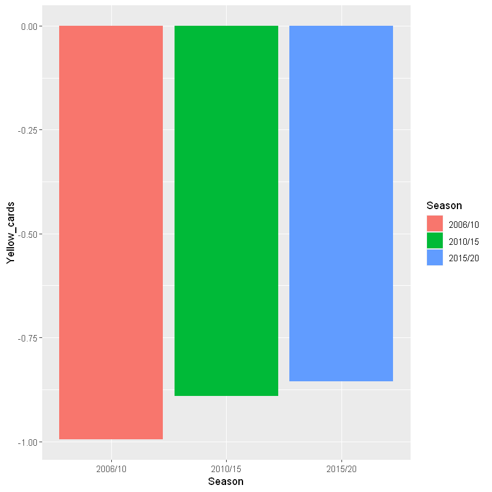

```r
ggplot(Correlation, aes(Season,Yellow_cards,fill=Season))+geom_bar(stat="identity")
```

## 순위변화 : 점유율

- 점유율 상관 순위가 과거부터 4, 7, 5등으로 과거부터 순위가 크게 감소했다가 최근 다시 증가한 추세를 보임
- 하지만 세 집단 모두 상관 절대값이 0.8이상으로 큰 상관을 보이고 있으며, 여전히 높은 상관을 보임

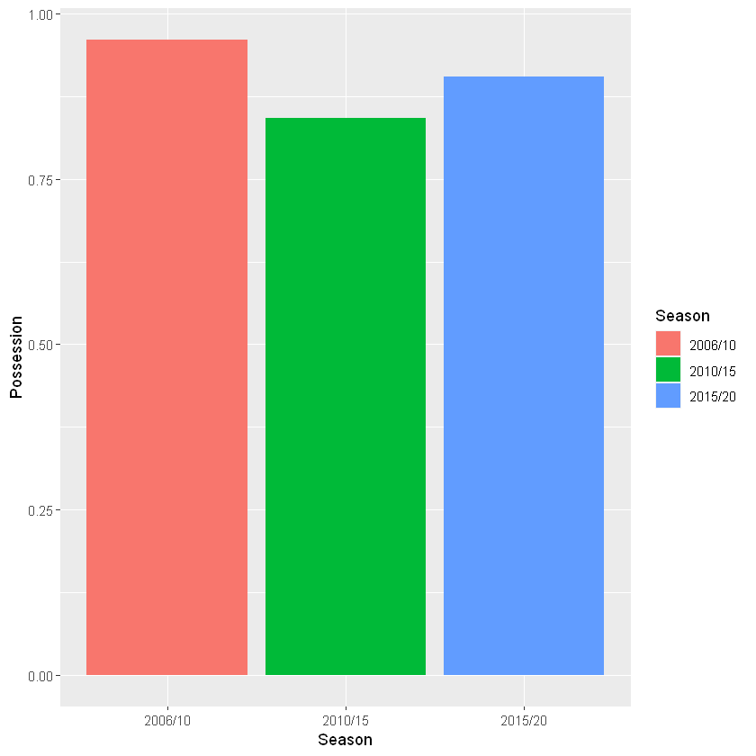

```r
ggplot(Correlation, aes(Season,Possession,fill=Season))+geom_bar(stat="identity")
```

## 수치변화 : 클리어링

- 클리어링은 2010~2015 시즌에 아주 높은 상관을 보임
- 해당 시즌에는 상대 공격팀의 볼을 걷어내는 수비 플레이의 수행이 승률에 높은 상관이 있음을 알 수 있음
- 최근에 들어서는 다시 감소중

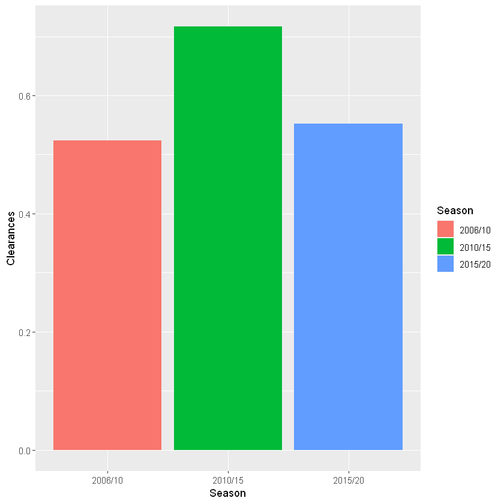

```r
ggplot(Correlation, aes(Season,Clearances,fill=Season))+geom_bar(stat="identity")
```

## 수치변화 : 파울

- 파울은 2006~2010 시즌에 아주 높은 상관을 보임
- 해당 시즌에서 파울이 많을 경우 승률에 큰 상관을 보였지만 그 후 최근 10년 간 감소된 추세를 보임

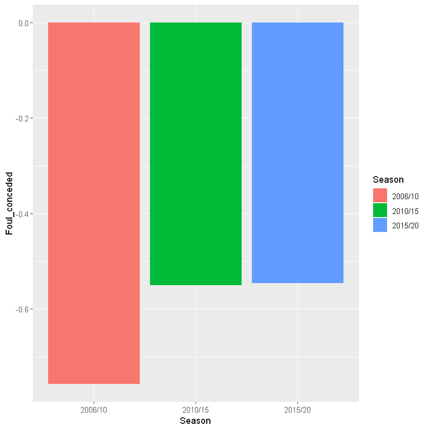

```r
ggplot(Correlation, aes(Season,Foul_conceded,fill=Season))+geom_bar(stat="identity")
```

## 수치변화 : 오프사이드

- 오프사이드의 경우 과거 시즌에 승률에 매우 높은 상관을 보였음
- 하지만 최근 5개 시즌에서 거의 0에 수렴하여 승률과 상관이 없는 것으로 나타남

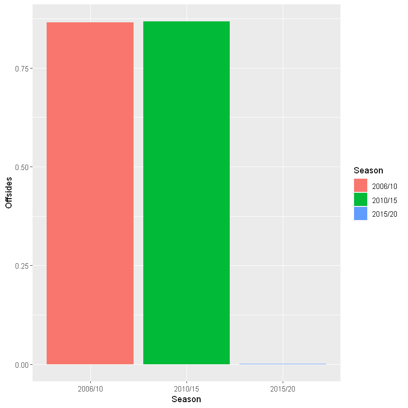

```r
ggplot(Correlation, aes(Season,Offsides,fill=Season))+geom_bar(stat="identity")
```

## 수치변화 : 코너킥

- 코너킥의 경우 과거부터 높은 상관을 지니며 점차 증가하여 아주 높은 상관을 지님
- 하지만 최근 5개 시즌에서는 그 상관이 많이 감소

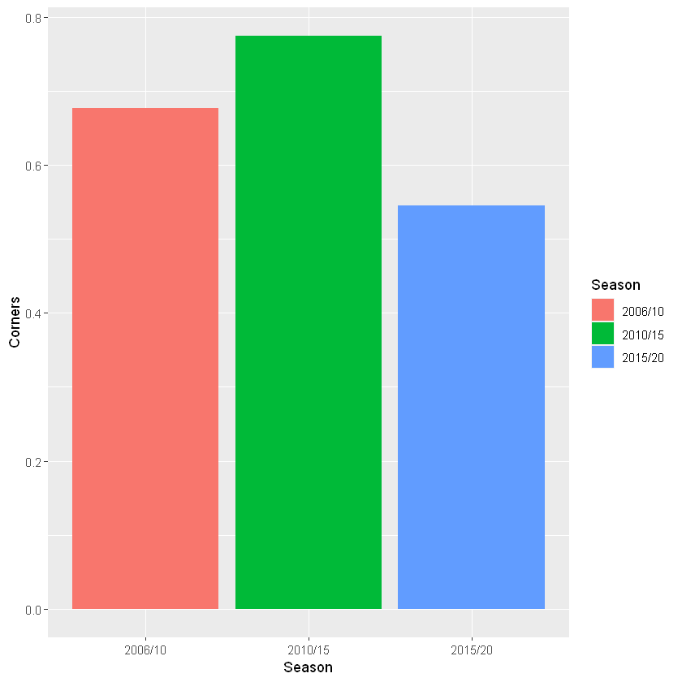

```r
ggplot(Correlation, aes(Season,Corners,fill=Season))+geom_bar(stat="identity")
```